# Pertemuan 4-Visualisasi Data

Author

Fitri Diana Musa

Published

September 10, 2026

# A. Recall Materi

1. Data munging/wrangling hanya dilakukan ketika terdapat missing value pada data.

   ☐ Benar ☐ Salah
2. Perhatikan data berikut.

   ```
   mahasiswa <- data.frame(
     nama = c("Andi", "Budi", "Citra", "Dina"),
     gender = c("L", "L", "P", "P"),
     nilai = c(78, 85, 90, 72)
   )
   ```

   Lalu dijalankan kode berikut:

   ```
   mahasiswa[mahasiswa$nilai > 80, ]
   ```

   Apa output yang akan dihasilkan?
3. Perhatikan kembali data `mahasiswa`. Jika kita ingin mengambil hanya kolom `nama` dan `nilai`, manakah kode yang tepat?

   ```
   a. mahasiswa[nama, nilai]
   ```

   ```
   b. mahasiswa[, c("nama", "nilai")]
   ```

   ```
   c. mahasiswa[c("nama", "nilai"), ]
   ```

   ```
   d. mahasiswa$nama$nilai
   ```

4. Perhatikan kode berikut.

   ```
   nama <- c("Andi  Saputra", "Budi   Santoso", "Citra  Dewi")

   gsub(" +", " ", nama)
   ```

   Apa tujuan penggunaan `gsub()` pada kode tersebut?

   A. Menghapus seluruh spasi  
   B. Mengganti nama mahasiswa  
   C. Mengubah beberapa spasi berturut-turut menjadi satu spasi  
   D. Mengurutkan nama mahasiswa
5. Perhatikan data berikut.

   ```
   data_nilai <- data.frame(
     nama = c("Ani", "Budi"),
     minggu1 = c(80, 75),
     minggu2 = c(85, 78),
     minggu3 = c(90, 82)
   )
   ```

   Bentuk data di atas termasuk:

   A. Long format  
   B. Wide format  
   C. Matrix format  
   D. Vector format
6. Pada proses data wrangling, fungsi `merge()` digunakan untuk menggabungkan dua data frame berdasarkan satu atau lebih variabel yang sama.

   ☐ Benar ☐ Salah
7. Fungsi `sort()` dapat digunakan untuk mengurutkan nilai dari yang terkecil ke terbesar maupun dari yang terbesar ke terkecil.

   ☐ Benar ☐ Salah

# B. Persiapan Praktikum

Pada praktikum ini kita akan menggunakan **R/RStudio**, package **`ggplot2`**. Package `ggplot2` perlu dipasang terlebih dahulu jika belum tersedia.

Instalasi dan memanggil `ggplot2` :

```
install.packages("ggplot2")   # cukup dilakukan sekali
library(ggplot2)
```

```r
#Jika ggplot2 sudah pernah diinstal, cukup jalankan:
library(ggplot2)
```

**Note**

**Catatan:** `install.packages()` digunakan untuk memasang package, sedangkan `library()` digunakan untuk memanggil package agar dapat digunakan dalam sesi R.

# C. Graphics Device

Dalam R, grafik ditampilkan pada suatu media yang disebut **graphics device**. Beberapa device yang tersedia antara lain `windows`, `X11`, `pdf`, `png`, dan `jpeg`.

Melihat device yang aktif:

```r
dev.list()
```

```r
dev.cur()
```

- `dev.list()` → melihat daftar graphics device yang sedang aktif.
- `dev.cur()` → melihat device yang sedang digunakan saat ini.

Contoh sederhana:

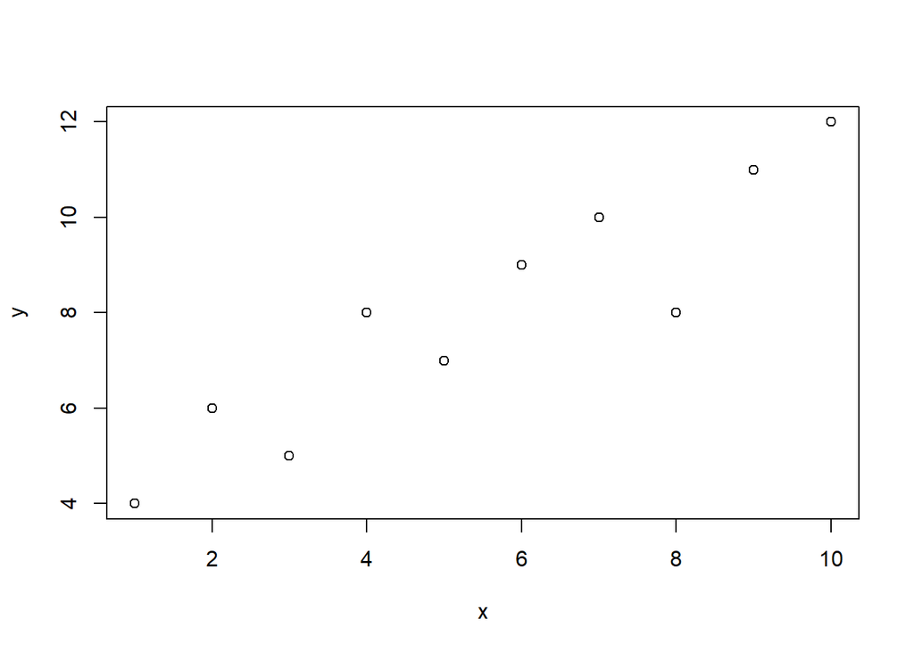

```r
x <- 1:10
y <- c(4, 6, 5, 8, 7, 9, 10, 8, 11, 12)

plot(x, y)
```

```r
dev.list()
```

```r
dev.cur()
```

Menutup graphics device:

```
# Untuk menutup device yang sedang aktif:
dev.off()

# Untuk menutup seluruh graphics device:
graphics.off()
```

**Note**

**Intinya:** graphics device adalah tempat R menampilkan atau menyimpan grafik. Untuk mengecek device gunakan `dev.list()` dan `dev.cur()`, sedangkan untuk menutupnya gunakan `dev.off()` atau `graphics.off()`.

# D. Fungsi Dasar `plot()`

Fungsi `plot()` merupakan fungsi dasar pada package `graphics` untuk membuat grafik di R.

Bentuk umumnya adalah:

```
plot(x, y, ...)
```

- `x` → data pada sumbu-X
- `y` → data pada sumbu-Y
- `...` → pengaturan tambahan pada grafik

Contoh:

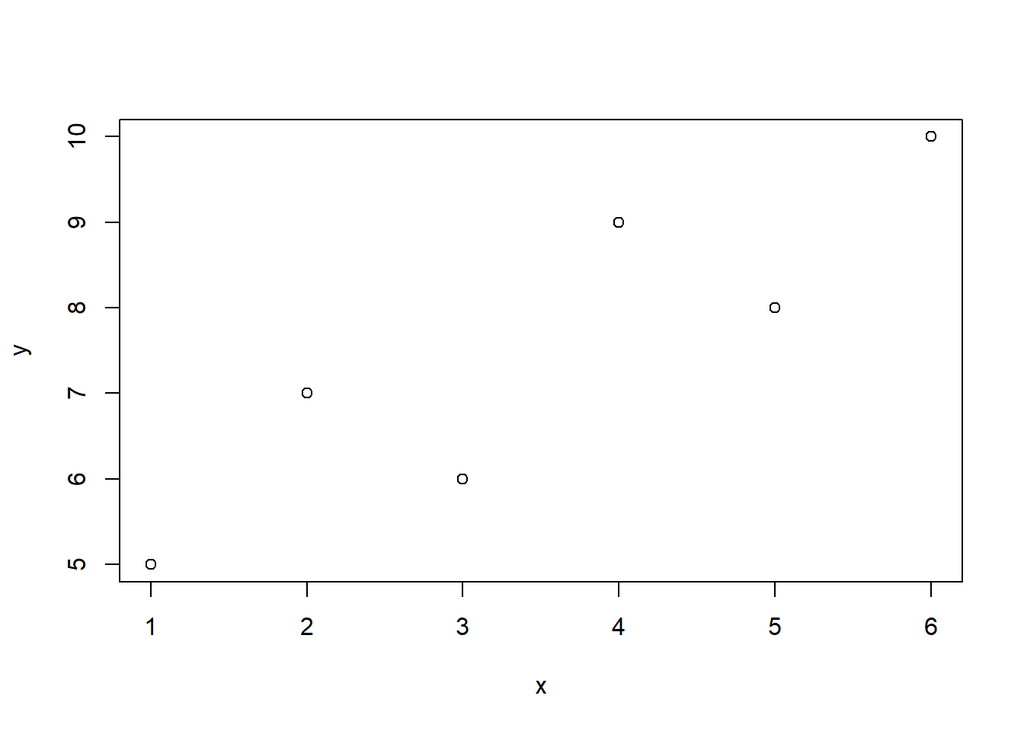

```r
x <- 1:6
y <- c(5, 7, 6, 9, 8, 10)

plot(x, y)
```

**Mengatur Bentuk Grafik dengan `type`**

Argumen `type` digunakan untuk menentukan bentuk grafik.

| `type` | Makna | Bentuk grafik |
| --- | --- | --- |
| `"p"` | **p = points** | Titik |
| `"l"` | **l = lines** | Garis |
| `"b"` | **b = both** | Titik dan garis |
| `"o"` | **o = overplotted** | Titik dan garis yang bertumpuk |
| `"n"` | **n = none** | Tidak menggambar objek |
| `"s"` | **s = steps** | Grafik tangga, segmen awal horizontal |
| `"S"` | **S = Steps** | Grafik tangga, segmen awal vertikal |
| `"h"` | **h = histogram-like** | Garis vertikal dari sumbu-X ke titik |

Contoh:

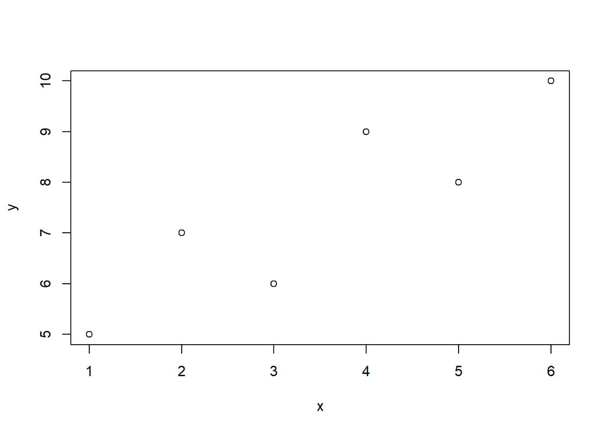

```r
plot(x, y, type = "p")
```

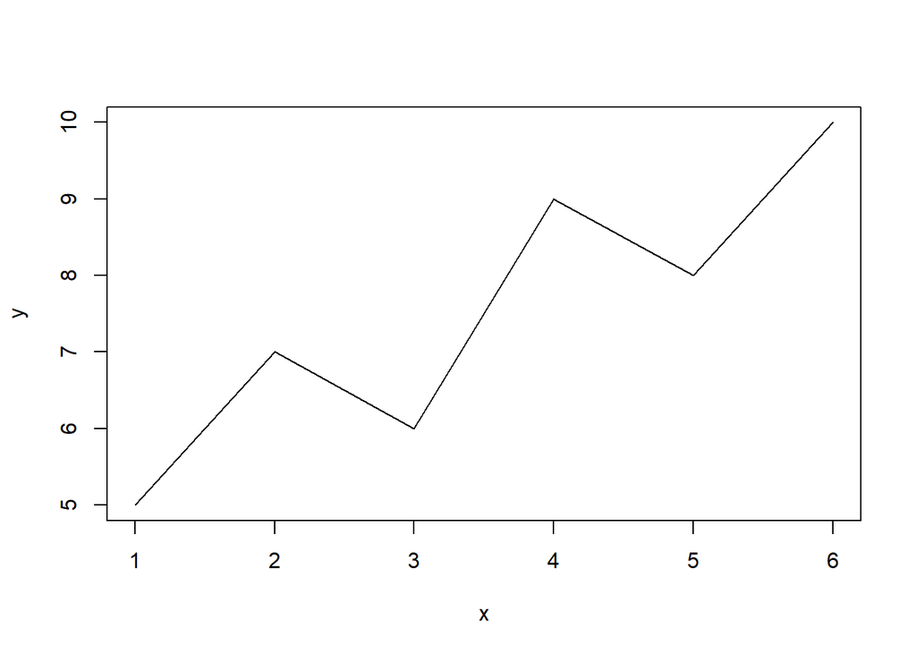

```r
plot(x, y, type = "l")
```

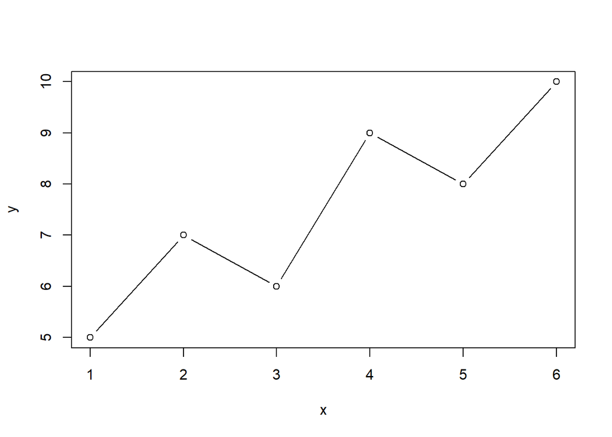

```r
plot(x, y, type = "b")
```

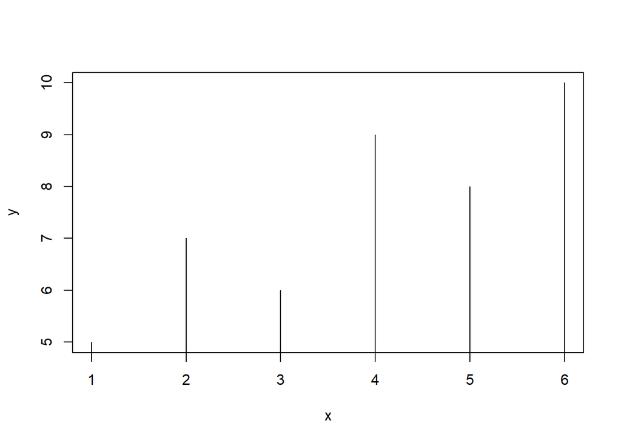

```r
plot(x, y, type = "h")
```

**Note**

**Intinya:** `plot()` digunakan untuk membuat grafik dasar, sedangkan `type` digunakan untuk menentukan bagaimana data ditampilkan pada grafik.

# E. Karakter Titik dan Garis

Tampilan titik dan garis pada grafik dapat diatur menggunakan beberapa parameter, yaitu `pch`, `cex`, `lty`, dan `lwd`.

## 1. Mengatur Titik

- `pch` (*plotting character*) → menentukan bentuk/simbol titik.
- `cex` (*character expansion*) → menentukan ukuran titik.

Contoh:

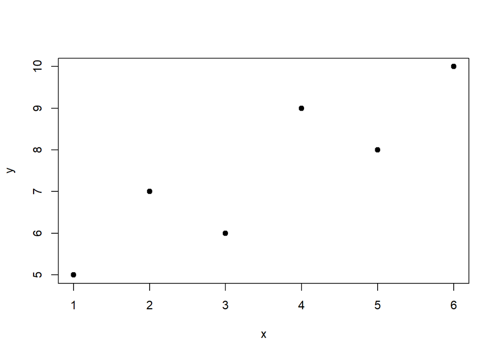

```r
x <- 1:6
y <- c(5, 7, 6, 9, 8, 10)

plot(x, y, pch = 19)
```

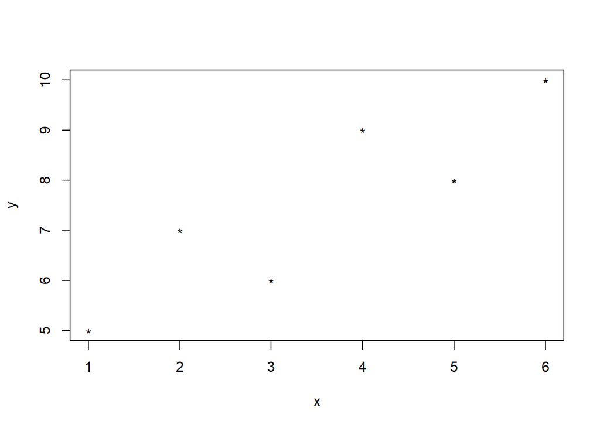

```r
plot(x, y, pch = "*")
```

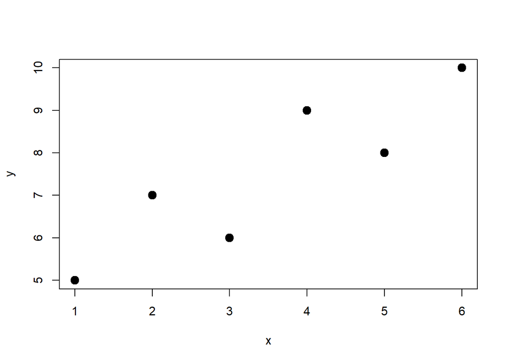

```r
plot(x, y, pch = 19, cex = 1.5)
```

## 2. Mengatur Garis

- `lty` (*line type*) → menentukan jenis garis.
- `lwd` (*line width*) → menentukan ketebalan garis.

Contoh:

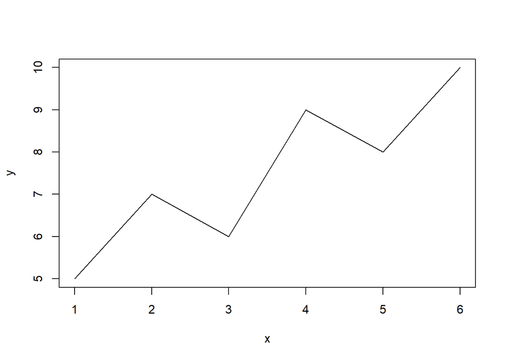

```r
plot(x, y, type = "l", lty = 1)
```

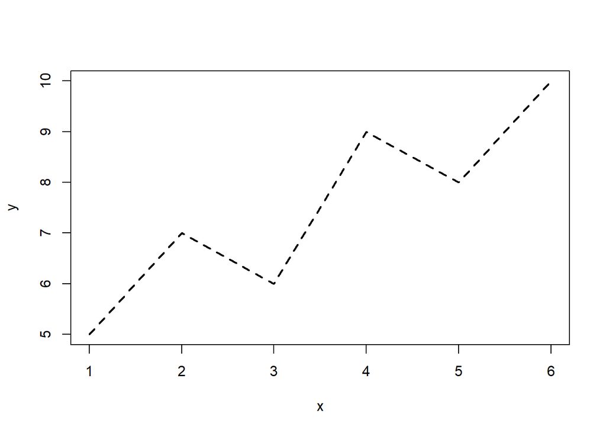

```r
plot(x, y,
     type = "l",
     lty = 2,
     lwd = 2)
```

# F. Parameter Grafik

Beberapa parameter pada `plot()` dapat digunakan untuk mengatur tampilan grafik, seperti rentang sumbu, warna, judul, dan label.

| Parameter | Kegunaan |
| --- | --- |
| `xlim` | Mengatur batas sumbu-X |
| `ylim` | Mengatur batas sumbu-Y |
| `col` | Mengatur warna |
| `main` | Memberikan judul utama |
| `sub` | Memberikan subjudul |
| `xlab` | Memberikan label sumbu-X |
| `ylab` | Memberikan label sumbu-Y |
| `axes` | Menampilkan atau menyembunyikan sumbu |

Contoh:

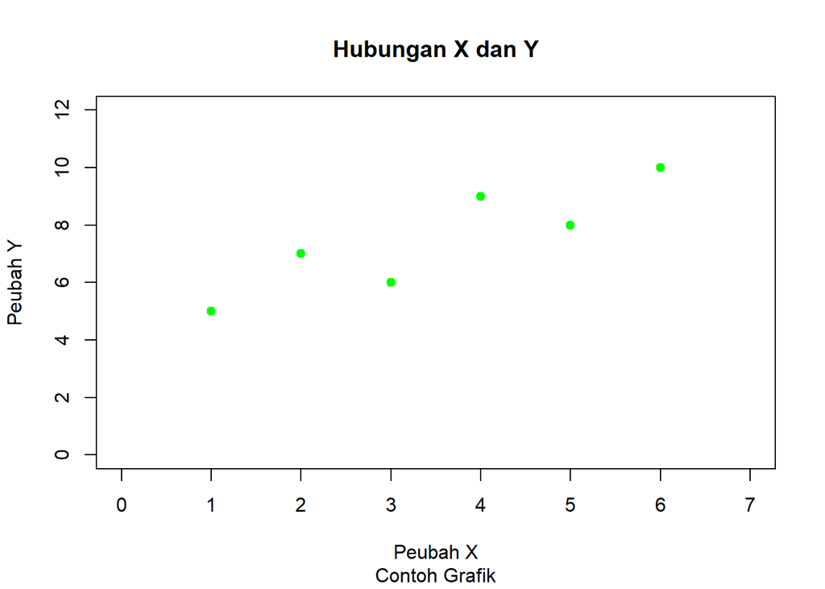

```r
x <- 1:6
y <- c(5, 7, 6, 9, 8, 10)

plot(
  x, y,
  pch = 19,
  col = "green",
  xlim = c(0, 7),
  ylim = c(0, 12),
  main = "Hubungan X dan Y",
  sub = "Contoh Grafik",
  xlab = "Peubah X",
  ylab = "Peubah Y"
)
```

Untuk melihat pilihan warna yang tersedia di R, gunakan:

```
colors()
```

# G. Menambahkan Elemen Grafik

Setelah grafik dibuat dengan `plot()`, kita dapat menambahkan elemen lain ke grafik yang sama menggunakan beberapa fungsi berikut.

| Fungsi | Kegunaan |
| --- | --- |
| `points()` | Menambahkan titik |
| `lines()` | Menambahkan garis |
| `abline()` | Menambahkan garis lurus |
| `segments()` | Menambahkan segmen garis |
| `arrows()` | Menambahkan garis berpanah |
| `polygon()` | Membuat poligon tertutup |
| `text()` | Menambahkan teks pada titik tertentu |
| `mtext()` | Menambahkan teks pada margin grafik |

Contoh:

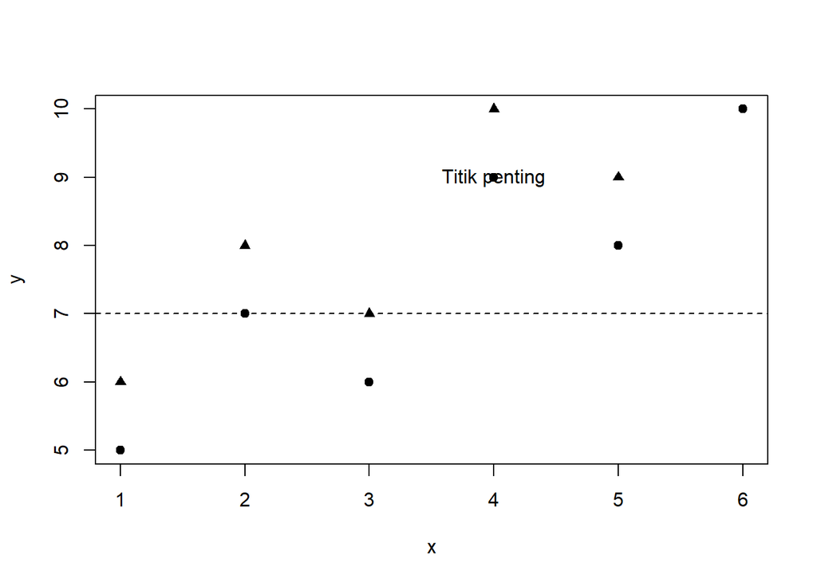

```r
x <- 1:6
y <- c(5, 7, 6, 9, 8, 10)

plot(x, y, pch = 19)

abline(h = 7, lty = 2)
points(x, y + 1, pch = 17)
text(4, 9, "Titik penting")
```

Pada contoh tersebut:

- `abline(h = 7)` menambahkan garis horizontal pada y=7
- `points()` menambahkan titik baru
- `text()` menambahkan keterangan pada grafik

# H. Membuat Sumbu secara Manual

Secara default, `plot()` akan menampilkan sumbu-X dan sumbu-Y secara otomatis. Jika ingin mengatur sumbu sendiri, gunakan `axes = FALSE`, lalu tambahkan sumbu dengan fungsi `axis()`.

Contoh:

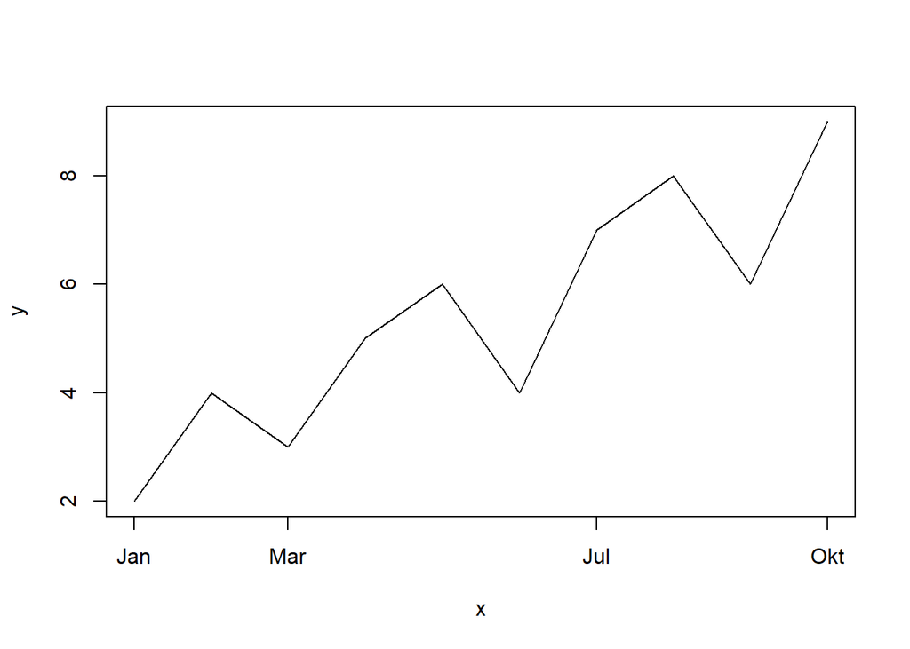

```r
x <- 1:10
y <- c(2, 4, 3, 5, 6, 4, 7, 8, 6, 9)

plot(x, y,
     type = "l",
     axes = FALSE)

axis(1,
     at = c(1, 3, 7, 10),
     labels = c("Jan", "Mar", "Jul", "Okt"))

axis(2,
     at = seq(0, 10, by = 2))

box()
```

**Note**

**Catatan:** `axis()` digunakan ketika kita ingin mengatur posisi dan label sumbu secara manual.

# I. Membuat Banyak Grafik dalam Satu Device

Beberapa grafik dapat ditampilkan dalam **satu area tampilan** menggunakan `par()`, `split.screen()`, atau `layout()`.

**Menggunakan `par(mfrow = ...)`**

Cara paling sederhana adalah menggunakan:

```
par(mfrow = c(baris, kolom))
```

Contoh:

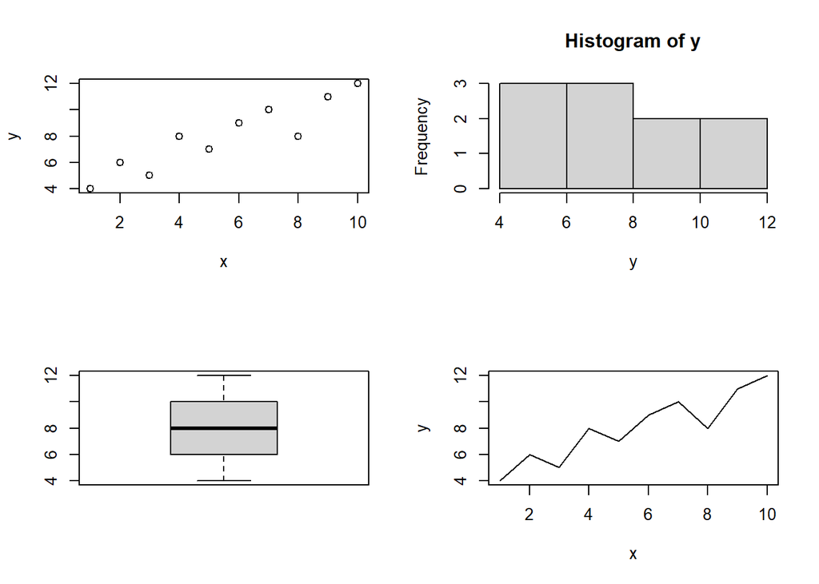

```r
x <- 1:10
y <- c(4, 6, 5, 8, 7, 9, 10, 8, 11, 12)

par(mfrow = c(2, 2))

plot(x, y)
hist(y)
boxplot(y)
plot(x, y, type = "l")
```

`par(mfrow = c(2, 2))` berarti tampilan dibagi menjadi **2 baris dan 2 kolom**, sehingga dapat menampilkan 4 grafik sekaligus.

Selain `par()`, dapat digunakan:

| Fungsi | Kegunaan |
| --- | --- |
| `par(mfrow = ...)` | Membagi area grafik menjadi beberapa bagian dengan ukuran sama |
| `split.screen()` | Membagi layar dan memilih area grafik secara manual |
| `layout()` | Mengatur posisi dan ukuran grafik dengan lebih fleksibel |

# J. Pengenalan `ggplot2` dan Grammar of Graphics

`ggplot2` adalah package visualisasi di R yang menggunakan konsep **Grammar of Graphics**, yaitu grafik dibangun dari beberapa komponen yang dapat digabungkan secara sistematis.

Empat komponen utama yang perlu dikenali adalah:

| Komponen | Kegunaan |
| --- | --- |
| `Geom` | Menentukan bentuk grafik, seperti titik, garis, atau batang |
| `Aesthetic (aes)` | Menghubungkan data dengan atribut visual seperti `x`, `y`, warna, bentuk, dan ukuran |
| `Stat` | Melakukan transformasi statistik sebelum data digambar |
| `Scale` | Mengatur hubungan antara nilai data dan tampilannya pada grafik |

## 1. Fungsi `geom_*`

Fungsi `geom_*` digunakan untuk menentukan **bentuk visual** yang akan ditampilkan pada grafik. Beberapa fungsi `geom_*` yang sering digunakan antara lain:

| Fungsi `geom_*` | Kegunaan |
| --- | --- |
| `geom_point()` | Membuat titik atau *scatter plot* |
| `geom_line()` | Membuat grafik garis |
| `geom_bar()` | Membuat grafik batang berdasarkan jumlah/frekuensi |
| `geom_col()` | Membuat grafik batang berdasarkan nilai yang sudah tersedia |
| `geom_boxplot()` | Membuat boxplot |
| `geom_histogram()` | Membuat histogram |

## 2. Fungsi `aes()`

`aes()` (*aesthetic mapping*) digunakan untuk **menghubungkan variabel dalam data dengan atribut visual**, seperti `x`, `y`, `color`, `shape`, dan `size`.

Contoh:

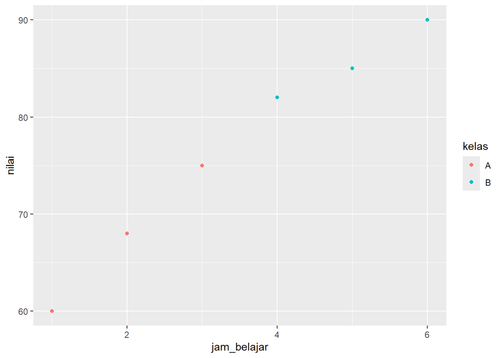

```r
data_nilai <- data.frame(
  jam_belajar = c(1, 2, 3, 4, 5, 6),
  nilai = c(60, 68, 75, 82, 85, 90),
  kelas = c("A", "A", "A", "B", "B", "B")
)

# Kode 1
ggplot(
  data_nilai,
  aes(x = jam_belajar, y = nilai, color = kelas)
) +
  geom_point()
```

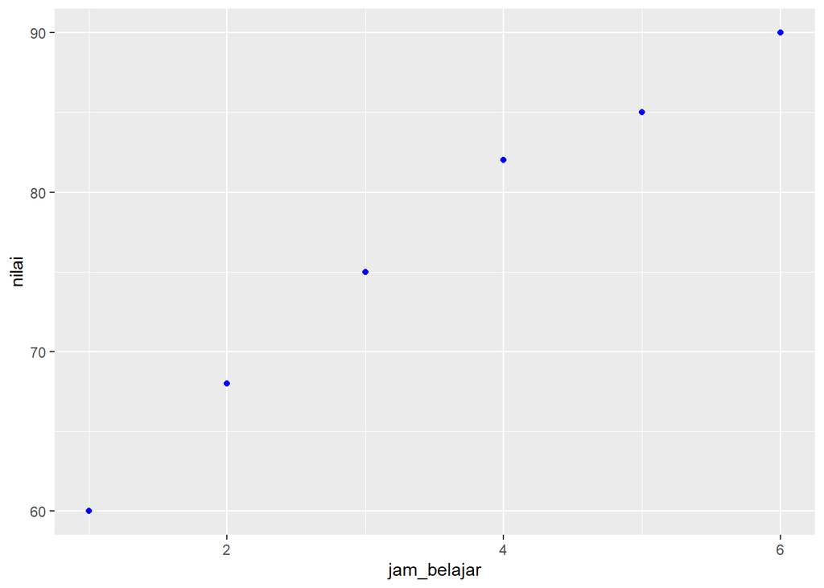

```r
# Kode 2
ggplot(data_nilai, aes(x = jam_belajar, y = nilai)) +
  geom_point(color = "blue")
```

## 3. Fungsi `stat_*`

Fungsi `stat_*` digunakan untuk melakukan **perhitungan atau transformasi statistik** sebelum data ditampilkan pada grafik.

| Fungsi `stat_*` | Kegunaan |
| --- | --- |
| `stat_smooth()` | Menambahkan garis tren atau pemulusan |
| `stat_bin()` | Mengelompokkan data ke dalam interval, seperti pada histogram |
| `stat_count()` | Menghitung frekuensi setiap kategori |
| `stat_summary()` | Menampilkan ringkasan statistik |

Pada `ggplot2`, `geom_*` dan `stat_*` biasanya sudah saling terhubung. Contohnya:

- `geom_bar()` secara default menggunakan `stat = "count"` untuk menghitung frekuensi setiap kategori.
- `geom_histogram()` secara default menggunakan `stat = "bin"` untuk membagi data ke dalam beberapa interval.

Untuk melihat fungsi `geom_*` dan `stat_*` yang tersedia, kita dapat menggunakan `apropos()`:

```r
# Melihat fungsi geom
apropos("^geom_")
```

```
 [1] "geom_abline"            "geom_area"              "geom_bar"
 [4] "geom_bin_2d"            "geom_bin2d"             "geom_blank"
 [7] "geom_boxplot"           "geom_col"               "geom_contour"
[10] "geom_contour_filled"    "geom_count"             "geom_crossbar"
[13] "geom_curve"             "geom_density"           "geom_density_2d"
[16] "geom_density_2d_filled" "geom_density2d"         "geom_density2d_filled"
[19] "geom_dotplot"           "geom_errorbar"          "geom_errorbarh"
[22] "geom_freqpoly"          "geom_function"          "geom_hex"
[25] "geom_histogram"         "geom_hline"             "geom_jitter"
[28] "geom_label"             "geom_line"              "geom_linerange"
[31] "geom_map"               "geom_path"              "geom_point"
[34] "geom_pointrange"        "geom_polygon"           "geom_qq"
[37] "geom_qq_line"           "geom_quantile"          "geom_raster"
[40] "geom_rect"              "geom_ribbon"            "geom_rug"
[43] "geom_segment"           "geom_sf"                "geom_sf_label"
[46] "geom_sf_text"           "geom_smooth"            "geom_spoke"
[49] "geom_step"              "geom_text"              "geom_tile"
[52] "geom_violin"            "geom_vline"
```

```r
# Melihat fungsi stat
apropos("^stat_")
```

```
 [1] "stat_align"             "stat_bin"               "stat_bin_2d"
 [4] "stat_bin_hex"           "stat_bin2d"             "stat_binhex"
 [7] "stat_boxplot"           "stat_connect"           "stat_contour"
[10] "stat_contour_filled"    "stat_count"             "stat_density"
[13] "stat_density_2d"        "stat_density_2d_filled" "stat_density2d"
[16] "stat_density2d_filled"  "stat_ecdf"              "stat_ellipse"
[19] "stat_function"          "stat_identity"          "stat_manual"
[22] "stat_qq"                "stat_qq_line"           "stat_quantile"
[25] "stat_sf"                "stat_sf_coordinates"    "stat_smooth"
[28] "stat_spoke"             "stat_sum"               "stat_summary"
[31] "stat_summary_2d"        "stat_summary_bin"       "stat_summary_hex"
[34] "stat_summary2d"         "stat_unique"            "stat_ydensity"
```

## 4. Fungsi `scale`

`scale` digunakan untuk mengatur **bagaimana nilai data diterjemahkan ke tampilan grafik**, misalnya warna, label sumbu, atau ukuran.

Contoh:

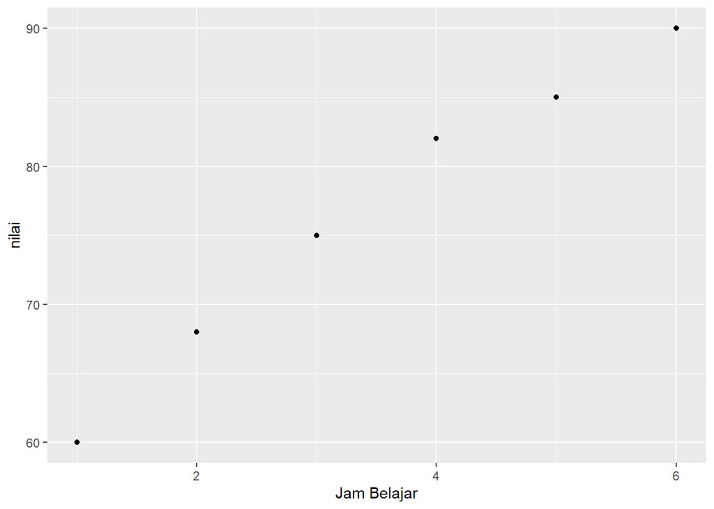

```r
# mengubah label sumbu
ggplot(data_nilai, aes(x = jam_belajar, y = nilai)) +
  geom_point() +
  scale_x_continuous(name = "Jam Belajar")
```

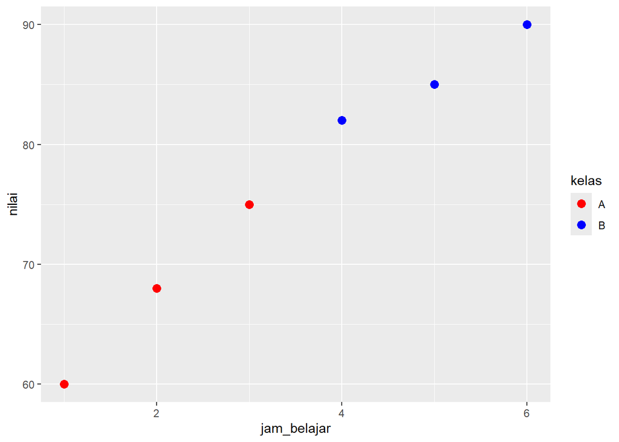

```r
# mengatur warna kategori
ggplot(
  data_nilai,
  aes(x = jam_belajar, y = nilai, color = kelas)
) +
  geom_point(size = 3) +
  scale_color_manual(
    values = c("red", "blue")
  )
```

Perbedaan utama antara `plot()` dengan `ggplot2`:

| `plot()` | `ggplot2` |
| --- | --- |
| Grafik dibuat secara langsung | Grafik dibangun bertahap dari beberapa komponen |
| Sintaks lebih sederhana untuk grafik dasar | Sintaks lebih terstruktur dan fleksibel |
| Modifikasi ditambahkan dengan fungsi seperti `points()`, `lines()`, `abline()` | Modifikasi ditambahkan sebagai *layer* menggunakan `+` |
| Cocok untuk grafik sederhana dan cepat | Cocok untuk grafik yang lebih kompleks dan mudah dikustomisasi |

# K. Eksplorasi Cepat dengan `qplot()`

Fungsi `qplot()` (*quick plot*) digunakan untuk membuat grafik secara **cepat dan sederhana** dengan `ggplot2`. Fungsi ini cocok untuk eksplorasi awal sebelum menggunakan `ggplot()` yang lebih lengkap.

Contoh:

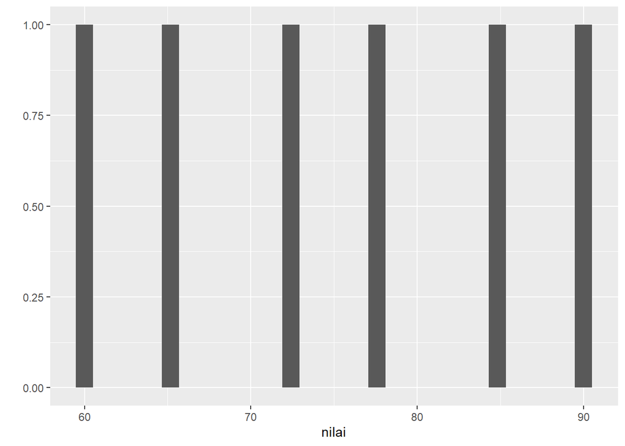

```r
data_nilai <- data.frame(
  jam_belajar = c(1, 2, 3, 4, 5, 6),
  nilai = c(60, 65, 72, 78, 85, 90),
  kelas = c("A", "A", "A", "B", "B", "B")
)

# Melihat Distribusi Nilai
qplot(
  x = nilai,
  data = data_nilai
)
```

**Note**

`qplot()` digunakan ketika kita ingin membuat visualisasi dengan cepat, sedangkan untuk pengaturan grafik yang lebih lengkap kita menggunakan `ggplot()`.

# L. Faceting

**Faceting** digunakan untuk membagi satu grafik menjadi beberapa **subgrafik** berdasarkan kategori tertentu. Dengan cara ini, pola antar kelompok menjadi lebih mudah dibandingkan.

Ada dua fungsi utama:

| Fungsi | Kegunaan |
| --- | --- |
| `facet_wrap()` | Membagi grafik berdasarkan **satu variabel kategori** |
| `facet_grid()` | Membagi grafik berdasarkan **dua variabel kategori**, dalam bentuk baris dan kolom |

Contoh:

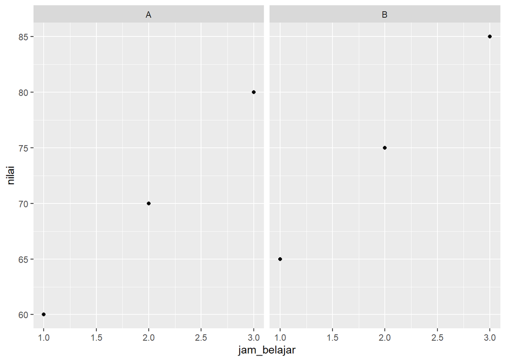

```r
# facet_wrap()
data_nilai <- data.frame(
  jam_belajar = c(1, 2, 3, 1, 2, 3),
  nilai = c(60, 70, 80, 65, 75, 85),
  kelas = c("A", "A", "A", "B", "B", "B")
)

ggplot(data_nilai,
       aes(x = jam_belajar, y = nilai)) +
  geom_point() +
  facet_wrap(~ kelas)
```

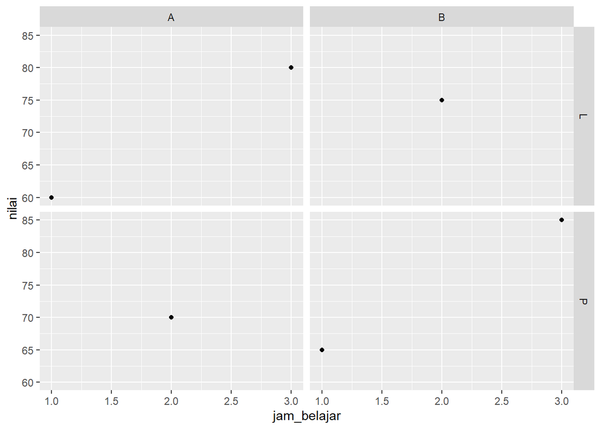

```r
# facet_grid()
# Misalkan ditambahkan variabel gender
data_nilai$gender <- c("L", "P", "L", "P", "L", "P")

ggplot(data_nilai,
       aes(x = jam_belajar, y = nilai)) +
  geom_point() +
  facet_grid(gender ~ kelas)
```

# M. Sistem Koordinat

Pada `ggplot2`, fungsi `coord_*` digunakan untuk mengatur **cara grafik ditampilkan dalam sistem koordinat tertentu**. Beberapa fungsi yang umum digunakan adalah:

| Fungsi | Kegunaan |
| --- | --- |
| `coord_flip()` | Membalik sumbu X dan Y |
| `coord_cartesian()` | Membatasi area tampilan |
| `coord_fixed()` | Menjaga rasio sumbu |
| `coord_polar()` | Membuat koordinat melingkar |

# N. Menyimpan Grafik

Grafik yang dibuat dengan `ggplot2` dapat disimpan menggunakan fungsi `ggsave()`. Format yang didukung antara lain **PNG, PDF, SVG, EPS, dan JPEG**.

Sintaks umum:

```
ggsave(filename, plot, width, height, dpi)
```

Keterangan:

| Argumen | Kegunaan |
| --- | --- |
| `filename` | Nama dan format file |
| `plot` | Grafik yang ingin disimpan |
| `width` | Lebar grafik |
| `height` | Tinggi grafik |
| `dpi` | Resolusi gambar |

Contoh:

```r
ggsave("grafik_nilai.png")
```

Untuk melihat lokasi penyimpanan gunakan:

```r
getwd()
```

```
[1] "D:/PASCASARJANA/ASPRAK/PEMOGRAMAN STATISTIKA/PRAKTIKUM UTS"
```

Jika ingin menentukan lokasi sendiri bisa langsung menuliskan lokasi folder pada `filename`:

```r
ggsave(
  "D:/PASCASARJANA/ASPRAK/PEMOGRAMAN STATISTIKA/PRAKTIKUM UTS/grafik_nilai2.png",
  width = 7,
  height = 5,
  dpi = 300
)
```

# O. Mengatur Tampilan dengan `theme()`

Fungsi `theme()` digunakan untuk mengatur **tampilan akhir grafik**, misalnya ukuran teks, posisi judul, legenda, grid, dan margin.

| Fungsi | Keterangan singkat |
| --- | --- |
| `theme_gray()` | Tema default `ggplot2` |
| `theme_bw()` | Latar putih, garis hitam |
| `theme_minimal()` | Sederhana dan bersih |
| `theme_void()` | Hampir tanpa sumbu dan latar |
| `theme_classic()` | Tampilan klasik dengan sumbu, tanpa grid |
| `theme_light()` | Latar terang dengan grid tipis |
| `theme_dark()` | Latar gelap |
| `theme_linedraw()` | Tampilan hitam-putih dengan garis tegas |

# P. Latihan Soal

Gunakan dataset bawaan R `mtcars` untuk mengerjakan latihan berikut.

1. Tampilkan 6 baris pertama dan 6 baris terakhir dari dataset `mtcars`, kemudian buat grafik menggunakan `plot()` untuk melihat hubungan antara `wt` sebagai sumbu-X dan `mpg` sebagai sumbu-Y serta berikan judul “Hubungan Berat Mobil dan Efisiensi Bahan Bakar”.
2. Buat scatter plot antara `hp` dan `mpg` menggunakan base R dengan ketentuan:
   - gunakan `pch = 19`;
   - ukuran titik `cex = 1.2`;
   - tentukan satu warna yang Anda inginkan;
   - berikan judul dan label pada kedua sumbu.
3. Buat scatter plot antara `wt` dan `mpg`, kemudian:
   - tambahkan garis horizontal pada nilai rata-rata `mpg`;
   - gunakan garis putus-putus;
   - tambahkan teks **“Rata-rata MPG”** di sekitar garis tersebut.
4. Gunakan:

   ```
   par(mfrow = c(..., ...))
   ```

   untuk menampilkan dua grafik berikut dalam satu tampilan:
   - scatter plot wt terhadap mpg;
   - histogram mpg;
5. Buat scatter plot menggunakan `ggplot2` untuk melihat hubungan antara `wt` dan `mpg`.

   Kemudian tambahkan informasi berikut:
   - warna titik berdasarkan `cyl`;
   - bentuk titik berdasarkan `am`;
   - ukuran titik berdasarkan `hp`.

# Q. Tugas Kedua

## 1. Ketentuan Tugas

- Tugas dikerjakan secara berkelompok. Setiap kelompok dipersilakan memilih satu orang ketua kelompok.
- Setiap mahasiswa yang mengikuti praktikum wajib memiliki satu repository GitHub dengan format nama:

  ```
  Praktikum-STA2561-NIM
  ```

  Repository tersebut digunakan untuk menyimpan tugas-tugas selama Praktikum Pemrograman Statistika.
- Khusus untuk tugas kedua ini, hasil pengerjaan cukup diunggah ke repository milik ketua kelompok. Anggota kelompok lainnya tidak perlu mengunggah ulang tugas yang sama ke repository masing-masing.
- File yang wajib tersedia di repository ketua kelompok adalah:
  - File **HTML** hasil pengerjaan tugas dengan format nama:

    ```
    kelompok0.html
    ```

    Notes: Ganti angka `0` dengan nomor kelompok masing-masing.  
    Pada bagian awal file HTML, wajib dicantumkan **NAMA-NIM seluruh anggota kelompok**.
  - `nilai_bersih.csv`
  - `profil_filter.csv`
  - `penjualan_long.csv`
  - **`co2_uptake_visualisasi.png`**
- PJ kelas bertugas membuat daftar yang berisi link GitHub Pages dari masing-masing ketua kelompok, kemudian mengirimkan daftar tersebut kepada saya.

  Contoh format link GitHub Pages:

  ```
  https://fitridianamusa.github.io/Praktikum-STA2561-M0501251054/kelompok0.html
  ```

  **Batas waktu pelaporan oleh PJ kelas: Rabu, 16 September 2026 pukul 20.00 WIB.**
- Pada Pertemuan 5, Kamis, 17 September 2026, akan dipilih 1 kelompok secara acak untuk mempresentasikan hasil pengerjaan tugas kelompoknya dengan durasi maksimal 15 menit. Seluruh anggota kelompok diharapkan memahami tugas yang telah dikerjakan.

## 2. Soal Tugas

**Soal 1**. Pembersihan Data Mahasiswa

Diberikan dataset mentah pada Tabel 1 berikut.

Tabel 1. Dataset Nilai Mahasiswa

| Nama | Matematika | Statistika | Umur |
| --- | --- | --- | --- |
| Andi | 80 | 85 | 21 |
| Budi | 90 | 88 | 20 |
| Citra | NA | 78 | 22 |
| Dewi | 75 | - | 21 |
| Andi | 80 | 85 | 21 |

Lakukan tahapan berikut.

1. Buat data frame bernama `nilai_raw` secara manual di R berdasarkan Tabel 1.
2. Identifikasi nilai yang hilang pada dataset secara sistematis. Ubah tanda hubung (`"-"`) pada nilai Statistika milik Dewi menjadi nilai hilang standar R, yaitu `NA`.
3. Lakukan imputasi terhadap nilai `Statistika` yang kosong menggunakan rata-rata nilai Statistika mahasiswa lainnya yang tersedia.
4. Buat kolom baru bernama `Status_Umur` menggunakan fungsi `ifelse()` dengan ketentuan:  
   `Dewasa` jika umur ≥ 21 tahun;  
   `Muda` jika umur < 21 tahun.
5. Identifikasi dan hapus baris pengamatan yang duplikat.
6. Simpan dataset yang telah dibersihkan ke dalam file bernama **`nilai_bersih.csv`**.

**Soal 2**. Subsetting dan Pengurutan Multikriteria

Gunakan dataset `profil` pada Tabel 2 berikut.

Tabel 2. Dataset Profil

| No | gender | v1 | v2 | v3 | v4 | v5 | v6 | v7 | v8 | v9 | v10 |
| --- | --- | --- | --- | --- | --- | --- | --- | --- | --- | --- | --- |
| 1 | f | 8 | 9 | 5 | 9 | 9 | 9 | 5 | 9 | 11 | 8 |
| 2 | f | 15 | 8 | 9 | 5 | 10 | 8 | 10 | 12 | 9 | 15 |
| 3 | f | 8 | 13 | 12 | 6 | 7 | 9 | 14 | 12 | 12 | 9 |
| 4 | m | 14 | 9 | 8 | NA | 11 | 10 | 6 | 11 | 11 | 8 |
| 5 | m | 8 | 2 | 9 | 16 | 8 | 10 | 8 | 9 | 8 | 9 |
| 6 | f | 10 | 6 | 10 | 9 | 10 | 10 | 9 | 7 | 7 | 11 |
| 7 | m | 9 | 9 | 7 | 13 | 9 | 12 | 10 | 9 | 11 | 7 |
| 8 | m | 9 | 10 | 8 | 10 | 5 | 10 | 6 | 12 | 6 | 8 |
| 9 | f | 10 | 13 | 6 | 7 | 10 | 12 | 13 | 9 | 6 | 9 |
| 10 | m | 12 | 10 | 9 | 8 | 17 | 7 | 9 | 10 | 7 | 7 |

Lakukan tahapan berikut.

1. Buat data frame bernama `profil` secara manual di R berdasarkan Tabel 2.
2. Lakukan penyaringan (subsetting) sehingga hanya menyisakan pengamatan yang memenuhi salah satu kondisi berikut:  
   gender laki-laki `(m)` dan `v1 > 9` ; atau  
   gender perempuan `(f)` dan `v3 <= 10`.
3. Urutkan data hasil penyaringan secara multikriteria, dengan ketentuan:  
   `gender` diurutkan secara *descending*;  
   untuk pengamatan dengan `gender` yang sama, `v5` diurutkan secara *ascending*.
4. Simpan hasil akhir ke dalam file bernama **`profil_filter.csv`**.

**Soal 3**. Penggabungan dan Reshaping Data

Diberikan dua data frame mengenai skor penjualan mingguan beberapa toko berikut.

```
df_sales <- data.frame(
  id_toko = c("T1", "T2", "T3"),
  Minggu1 = c(120, 150, 95),
  Minggu2 = c(135, 140, 110)
)

df_info <- data.frame(
  id = c("T1", "T2", "T4"),
  Kota = c("Jakarta", "Bandung", "Surabaya")
)
```

Lakukan tahapan berikut.

1. Gabungkan `df_sales` dan `df_info` menggunakan fungsi `merge()` dengan metode Full Outer Join, sehingga seluruh toko dari kedua data frame tetap disertakan.  
   Perhatikan bahwa nama variabel kunci pada kedua data frame berbeda, yaitu `id_toko` pada `df_sales` dan `id` pada `df_info`. Gunakan argumen penggabungan yang sesuai.
2. Ubah struktur data hasil penggabungan dari format Wide menjadi Long, sehingga:  
   `Minggu1` dan `Minggu2` digabung menjadi satu kolom bernama `Waktu`;  
   nilai penjualan disimpan dalam satu kolom bernama `Penjualan`.
3. Simpan dataset dalam format Long tersebut ke dalam file bernama **`penjualan_long.csv`**.

**Soal 4**. Eksplorasi Visual

Gunakan dataset bawaan R `CO2` untuk mengeksplorasi hubungan antara konsentrasi karbon dioksida (`conc`) dan tingkat penyerapan karbon dioksida (`uptake`) pada tanaman.

1. Kenali struktur dataset `CO2` dan identifikasi peran peubah `Plant`, `Type`, `Treatment`, `conc`, dan `uptake`, kemudian buat grafik menggunakan **base R** untuk menunjukkan hubungan `conc` dan `uptake` dengan mengatur bentuk dan ukuran titik, warna, judul, label sumbu, serta rentang sumbu, lalu tambahkan minimal **dua elemen grafik** menggunakan `points()`, `lines()`, `abline()`, atau `text()`.
2. Buat satu tampilan grafik berukuran **2 × 2** yang terdiri atas empat jenis visualisasi berbeda untuk mengeksplorasi `conc`, `uptake`, `Type`, dan `Treatment`; tentukan sendiri jenis grafik yang paling sesuai dan berikan judul yang jelas pada setiap grafik.
3. Gunakan `qplot()` untuk membuat visualisasi cepat hubungan `conc` dan `uptake` berdasarkan `Treatment`, kemudian buat kembali visualisasi tersebut menggunakan `ggplot2` dengan memetakan `Treatment` dan `Type` ke **atribut visual yang berbeda** di dalam `aes()` serta menggunakan `geom_*` yang sesuai.
4. Kembangkan grafik `ggplot2` tersebut dengan menambahkan minimal satu `stat_*`, satu `scale_*`, serta salah satu `coord_*`, kemudian lengkapi grafik menggunakan `labs()` dan `theme()` atau salah satu tema siap pakai agar grafik lebih informatif dan mudah dibaca.
5. Simpan grafik akhir menggunakan `ggsave()` dalam format PNG dengan nama **`co2_uptake_visualisasi.png`**, kemudian tuliskan interpretasi mengenai hubungan antara konsentrasi CO₂ dan `uptake` serta perbedaan pola yang terlihat berdasarkan `Type` dan `Treatment`.